# R Notebook - Linear Time Series TP1

# TP1 de séries temporelles linéaires

```r
rm(list = ls())
require(zoo) #format de serie temporelle pratique et facile d'utilisation (mais plus volumineux)
library("ggplot2")
library("tseries") # contient plus des fonctions pour séries temporelles
```

### Question 1 - importatation des données

```r
donnees1 = read.csv(file="./Donnees/Donnees1.csv")

xm.source = zoo(donnees1)
n = length(donnees1$XM) - 4
xm = zoo(donnees1$XM[1:n])
```

### Question 2 - désaisonnalisation

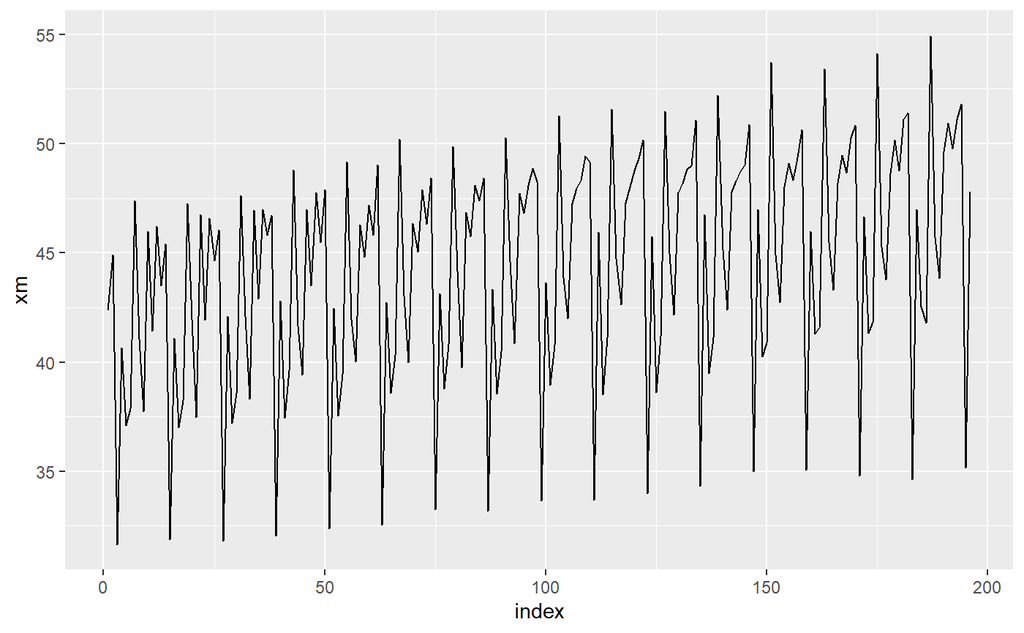

```r
index = 1:n
data_display = as.data.frame(cbind(index,xm))
p1 = ggplot(data = data_display) + geom_line(aes(x=index,y=xm))
p1
```

On observe une saisonnalité de 12 mois. Pour résoudre le problème de saisonnalité, on peut différencier la série avec un pas temporel de 12 mois.

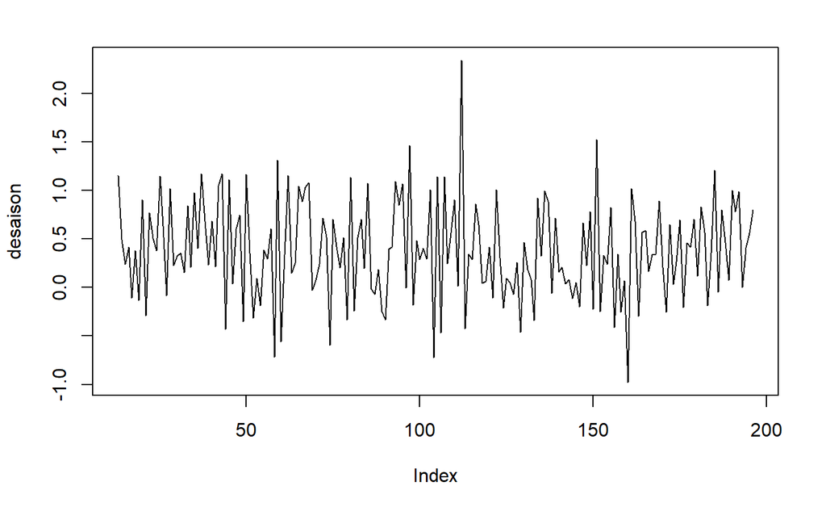

```r
desaison = xm - lag(xm,-12)
plot(desaison)
```

L’exercice suppose que desaison suit un ARIMA(p,d,q).

### Question 3

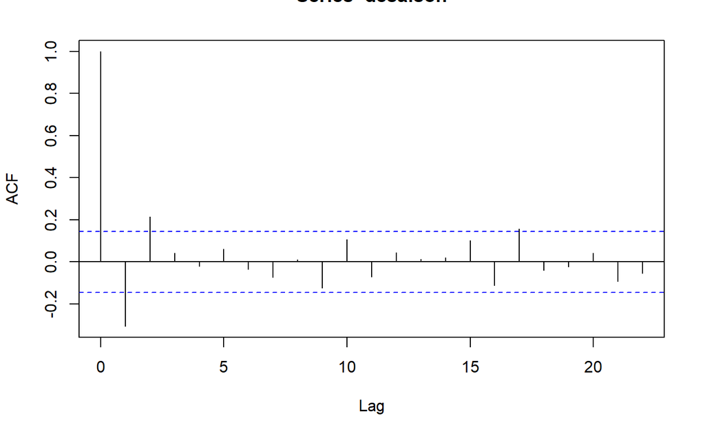

```r
acf(desaison)
```

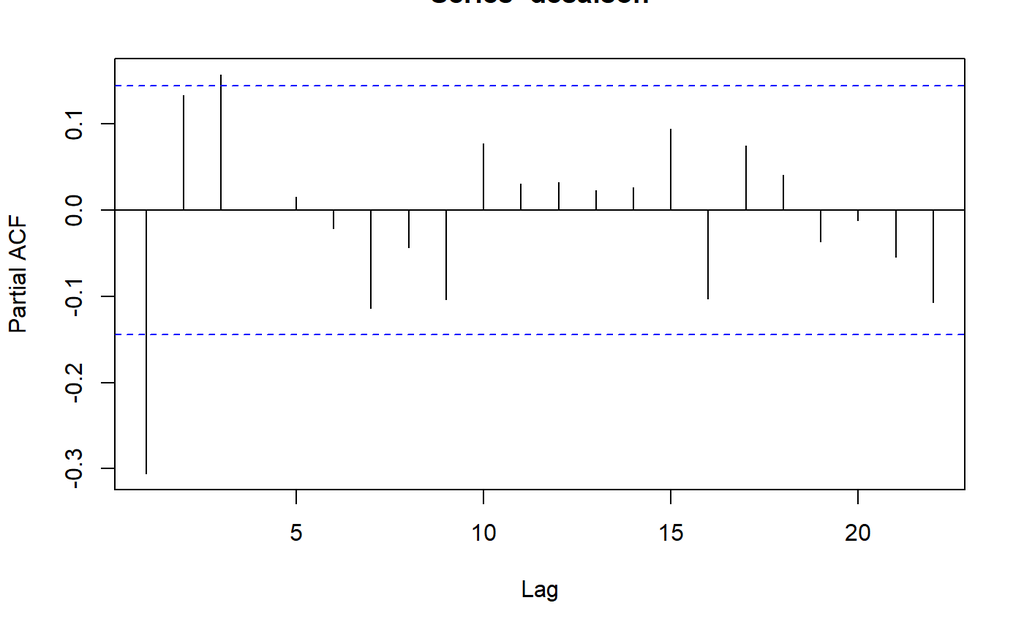

```r
pacf(desaison)
```

L’autocorrélogramme décroît à une vitesse exponentielle, donc la série semble maintenant bien stationnaire.

### Question 4 - test de racine unitaire

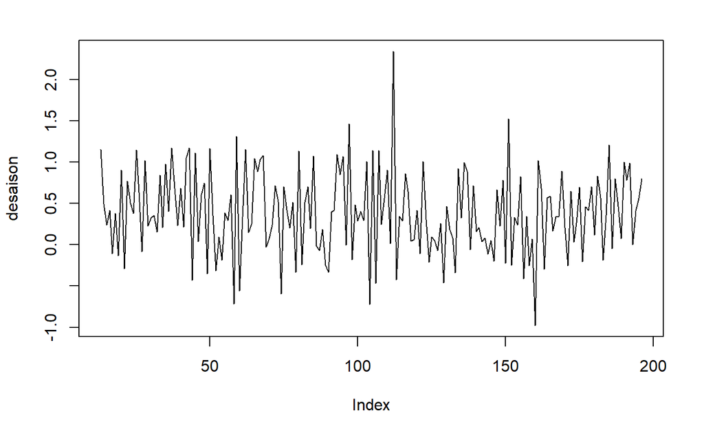

```r
plot(desaison)
```

```r
pp.test(desaison)
```

```
    Phillips-Perron Unit Root Test

data:  desaison
Dickey-Fuller Z(alpha) = -268.96, Truncation lag parameter = 4, p-value = 0.01
alternative hypothesis: stationary
```

*Test de Unit Root de Philips-Perront.*

On rejette de l’hypothèse nulle à 1%, qui était l’hypothèse de non-stationnarité.

Le test confirme donc bien les conclusions précédentes, la série est stationnaire.

### Question 5

En vertu du ACF, je prendrais $q=2$. Le PACF semble indiquer $p=3$.

Ainsi, on veut tester si la série suit bien un $ARIMA(3,0,2)$.

```r
arima302 = arima(desaison - mean(desaison), c(3,0,2))

stats::Box.test(arima302$residuals,lag = 6, type="Ljung-Box",fitdf = 5)
```

```
    Box-Ljung test

data:  arima302$residuals
X-squared = 0.40607, df = 1, p-value = 0.524
```

“Box.test” : permet d’utiliser les tests de Box-Pierce ou Ljung-Box, c’est-à-dire tester s’il y a encore de la dynamique dans les résidus. - fitdf : number of degrees of freedom to be substracted if $x$ is a series of residuals - donc ici fitdf = p+q = 5 - lag : the statistic will be based on $lag$ autoorrelation coefficients - $lag=k$ dans mes notes Obsidian sur ces tests

```r
Qtests <- function(series, k, fitdf = 0){
  my_func<- function(l){
    pval = if(l<=fitdf) NA else Box.test(series,lag = l, type ="Ljung-Box",fitdf=fitdf)$p.value
    return(c("lag"=l,"pval"=pval))
  }

  pvals <- apply(matrix(1:k), 1, FUN = my_func)
  return(t(pvals))
}

Qtests(arima302$residuals, 25, 5) # test de Ljung-Box pour les ordres de 1 à 24
```

```
      lag      pval
 [1,]   1        NA
 [2,]   2        NA
 [3,]   3        NA
 [4,]   4        NA
 [5,]   5        NA
 [6,]   6 0.5239728
 [7,]   7 0.2923972
 [8,]   8 0.3708128
 [9,]   9 0.3015618
[10,]  10 0.3096879
[11,]  11 0.4154275
[12,]  12 0.5294905
[13,]  13 0.6131866
[14,]  14 0.6179548
[15,]  15 0.6439982
[16,]  16 0.6600634
[17,]  17 0.4385724
[18,]  18 0.5197705
[19,]  19 0.5952434
[20,]  20 0.6660243
[21,]  21 0.5958363
[22,]  22 0.5016374
[23,]  23 0.5460007
[24,]  24 0.5417287
[25,]  25 0.4682566
```

```r
round(Qtests(arima302$residuals,24,fitdf=5),3)
```

```
      lag  pval
 [1,]   1    NA
 [2,]   2    NA
 [3,]   3    NA
 [4,]   4    NA
 [5,]   5    NA
 [6,]   6 0.524
 [7,]   7 0.292
 [8,]   8 0.371
 [9,]   9 0.302
[10,]  10 0.310
[11,]  11 0.415
[12,]  12 0.529
[13,]  13 0.613
[14,]  14 0.618
[15,]  15 0.644
[16,]  16 0.660
[17,]  17 0.439
[18,]  18 0.520
[19,]  19 0.595
[20,]  20 0.666
[21,]  21 0.596
[22,]  22 0.502
[23,]  23 0.546
[24,]  24 0.542
```

On fait plein de fois le test de Ljung-Box (pour tous les ordres).

On ne rejette à aucun niveau usuel l’indépendance des résidus, pour n’importe quel lag entre 5 et 24 !

Ainsi, le modèle semble assez riche (“valide” selon la correction) pour cette série temporelle.

### Question 6

Les sous-modèles possibles sont les suivants : - ARIMA(2,0,2) - ARIMA(1,0,2) - MA(0,2)

- ARIMA(3,0,1)
- ARIMA(2,0,1)
- ARIMA(1,0,1)
- MA(1)
- AR(3)
- AR(2)
- AR(1)
- ARIMA(0,0,0)

Pour choisir parmi ces modèles, il suffit de tester la nullité du coefficient p ou q du modèle actuellement considéré.

```r
signif <- function(estim){
  coef <- estim$coef
  se = sqrt(diag(estim$var.coef))
  t <- coef/se

  pval <- (1-pnorm(abs(t)))*2 # formule de la pvaleur pour un test de Student : on le retrouve facilement par le calcul
  return(rbind(coef,se,pval))
}

signif(arima302)
```

```
            ar1       ar2       ar3        ma1         ma2    intercept
coef -0.3069992 0.2090601 0.1747649 0.01781536 -0.03904574 0.0008088382
se    0.5420440 0.2489709 0.1603828 0.54880708  0.30813266 0.0368461190
pval  0.5711401 0.4010784 0.2758570 0.97410364  0.89916415 0.9824864146
```

On ne rejette pas que coefficient $\phi_p$ et $\psi_q$ sont non nuls.

*Correction* : Aucun coefficient n’est statistiquement significatif. Notre ARIMA(3,0,2) ne semble donc pas bien ajusté.

```r
y = desaison - mean(desaison)

arimafit <- function(estim){
  adjust <- round(signif(estim),3)
  pvals <- Qtests(estim$residuals,24,length(estim$coef)-1)
  pvals <- matrix(apply(matrix(1:24,nrow=6),2,function(c) round(pvals[c,],3)),nrow=6)
  colnames(pvals) <- rep(c("lag", "pval"),4)
  cat("tests de nullite des coefficients :\n")
  print(adjust)
  cat("\n tests d'absence d'autocorrelation des residus : \n")
  print(pvals)
}

estim <- arima(y,c(1,0,0)); arimafit(estim)
```

```
tests de nullite des coefficients :
        ar1 intercept
coef -0.309    -0.002
se    0.071     0.027
pval  0.000     0.955

 tests d'absence d'autocorrelation des residus :
     lag  pval lag  pval lag  pval lag  pval
[1,]   1    NA   7 0.082  13 0.209  19 0.205
[2,]   2 0.016   8 0.109  14 0.224  20 0.252
[3,]   3 0.015   9 0.077  15 0.203  21 0.184
[4,]   4 0.039  10 0.093  16 0.235  22 0.159
[5,]   5 0.064  11 0.127  17 0.128  23 0.182
[6,]   6 0.096  12 0.168  18 0.166  24 0.171
```

```r
#

estim <- arima(y,c(2,0,0)); arimafit(estim)
```

```
tests de nullite des coefficients :
        ar1   ar2 intercept
coef -0.267 0.133    -0.001
se    0.074 0.073     0.031
pval  0.000 0.071     0.985

 tests d'absence d'autocorrelation des residus :
     lag  pval lag  pval lag  pval lag  pval
[1,]   1    NA   7 0.230  13 0.469  19 0.393
[2,]   2    NA   8 0.295  14 0.481  20 0.444
[3,]   3 0.041   9 0.231  15 0.477  21 0.343
[4,]   4 0.116  10 0.246  16 0.485  22 0.329
[5,]   5 0.170  11 0.314  17 0.281  23 0.370
[6,]   6 0.247  12 0.396  18 0.344  24 0.363
```

```r
#

estim <- arima(y,c(3,0,0)); arimafit(estim)
```

```
tests de nullite des coefficients :
        ar1   ar2   ar3 intercept
coef -0.289 0.177 0.161     0.001
se    0.073 0.075 0.073     0.037
pval  0.000 0.019 0.028     0.983

 tests d'absence d'autocorrelation des residus :
     lag  pval lag  pval lag  pval lag  pval
[1,]   1    NA   7 0.653  13 0.790  19 0.737
[2,]   2    NA   8 0.681  14 0.786  20 0.792
[3,]   3    NA   9 0.567  15 0.799  21 0.730
[4,]   4 0.697  10 0.545  16 0.804  22 0.644
[5,]   5 0.872  11 0.640  17 0.602  23 0.682
[6,]   6 0.922  12 0.732  18 0.674  24 0.676
```

```r
#
ar3 <- estim

estim <- arima(y,c(0,0,1)); arimafit(estim)
```

```
tests de nullite des coefficients :
        ma1 intercept
coef -0.222    -0.002
se    0.059     0.028
pval  0.000     0.957

 tests d'absence d'autocorrelation des residus :
     lag  pval lag  pval lag  pval lag  pval
[1,]   1    NA   7 0.024  13 0.075  19 0.073
[2,]   2 0.001   8 0.039  14 0.093  20 0.097
[3,]   3 0.003   9 0.025  15 0.077  21 0.072
[4,]   4 0.007  10 0.029  16 0.087  22 0.068
[5,]   5 0.014  11 0.040  17 0.040  23 0.085
[6,]   6 0.024  12 0.055  18 0.055  24 0.073
```

```r
#

estim <- arima(y,c(0,0,2)); arimafit(estim)
```

```
tests de nullite des coefficients :
        ma1   ma2 intercept
coef -0.297 0.254     0.000
se    0.074 0.067     0.033
pval  0.000 0.000     0.998

 tests d'absence d'autocorrelation des residus :
     lag  pval lag  pval lag  pval lag  pval
[1,]   1    NA   7 0.665  13 0.801  19 0.741
[2,]   2    NA   8 0.701  14 0.800  20 0.790
[3,]   3 0.629   9 0.604  15 0.803  21 0.715
[4,]   4 0.860  10 0.579  16 0.803  22 0.659
[5,]   5 0.769  11 0.662  17 0.614  23 0.694
[6,]   6 0.846  12 0.746  18 0.684  24 0.692
```

```r
#
ma2 <- estim

estim <- arima(y,c(1,0,1)); arimafit(estim)
```

```
tests de nullite des coefficients :
        ar1   ma1 intercept
coef -0.495 0.201    -0.001
se    0.146 0.157     0.029
pval  0.001 0.201     0.966

 tests d'absence d'autocorrelation des residus :
     lag  pval lag  pval lag  pval lag  pval
[1,]   1    NA   7 0.106  13 0.280  19 0.255
[2,]   2    NA   8 0.144  14 0.295  20 0.305
[3,]   3 0.012   9 0.106  15 0.279  21 0.221
[4,]   4 0.043  10 0.125  16 0.307  22 0.203
[5,]   5 0.073  11 0.169  17 0.166  23 0.232
[6,]   6 0.114  12 0.225  18 0.213  24 0.223
```

```r
#

estim <- arima(y,c(1,0,2)); arimafit(estim)
```

```
tests de nullite des coefficients :
       ar1    ma1   ma2 intercept
coef 0.338 -0.628 0.327     0.001
se   0.332  0.327 0.095     0.037
pval 0.308  0.055 0.001     0.987

 tests d'absence d'autocorrelation des residus :
     lag  pval lag  pval lag  pval lag  pval
[1,]   1    NA   7 0.563  13 0.721  19 0.687
[2,]   2    NA   8 0.617  14 0.750  20 0.743
[3,]   3    NA   9 0.488  15 0.754  21 0.646
[4,]   4 0.571  10 0.466  16 0.746  22 0.569
[5,]   5 0.587  11 0.560  17 0.544  23 0.607
[6,]   6 0.749  12 0.650  18 0.619  24 0.604
```

```r
#

estim <- arima(y,c(2,0,1)); arimafit(estim)
```

```
tests de nullite des coefficients :
       ar1   ar2    ma1 intercept
coef 0.202 0.302 -0.476     0.001
se   0.202 0.082  0.202     0.037
pval 0.317 0.000  0.018     0.985

 tests d'absence d'autocorrelation des residus :
     lag  pval lag  pval lag  pval lag  pval
[1,]   1    NA   7 0.362  13 0.586  19 0.503
[2,]   2    NA   8 0.418  14 0.593  20 0.561
[3,]   3    NA   9 0.317  15 0.595  21 0.441
[4,]   4 0.221  10 0.329  16 0.603  22 0.398
[5,]   5 0.405  11 0.415  17 0.369  23 0.435
[6,]   6 0.493  12 0.510  18 0.442  24 0.428
```

```r
#
ar2ma1 <- estim

estim <- arima(y,c(2,0,2)); arimafit(estim)
```

```
tests de nullite des coefficients :
       ar1   ar2    ma1   ma2 intercept
coef 0.289 0.092 -0.583 0.246     0.001
se   0.268 0.177  0.266 0.176     0.037
pval 0.282 0.602  0.029 0.163     0.983

 tests d'absence d'autocorrelation des residus :
     lag  pval lag  pval lag  pval lag  pval
[1,]   1    NA   7 0.433  13 0.669  19 0.635
[2,]   2    NA   8 0.498  14 0.691  20 0.696
[3,]   3    NA   9 0.396  15 0.703  21 0.591
[4,]   4    NA  10 0.387  16 0.702  22 0.515
[5,]   5 0.421  11 0.488  17 0.485  23 0.553
[6,]   6 0.636  12 0.590  18 0.563  24 0.552
```

```r
#


#
models <- c("ar3","ma2","ar2ma1"); names(models) <- models
apply(as.matrix(models),1, function(m) c("AIC"=AIC(get(m)), "BIC"=BIC(get(m))))
```

```
         ar3      ma2   ar2ma1
AIC 256.6612 255.5774 258.6039
BIC 272.7359 268.4371 274.6786
```

Modèle AR(1) : bien ajusté mais pas valide, car autocorrélation des résidus Modèle AR(2) : même pas bien ajusté

Le modèle AR(3) est le premier modèle où les coefficients sont tous significatifs et dont les résidus ne semblent pas avoir d’autocorrélation. -> Modèle candidat A

MA(2) : les deux coefficients sont significatifs et pas d’autocorrélation des résidus. -> Modèle candidat B

Modèle sans autocorrrélation des résidus et avec des coefficients pas tous significatifs -> rejet du modèle, on ne le garde pas.

ARIMA(2,0,1) : on le garde pcq 2 coefs sur 3 significatifs et pas d’autocorrélation des résiduds

**Moi** : à mon avis, on garde un modèle qui a des coefficients non significiatifs, si le dernier coefficient de chaque ordre est bien significatif

### Question 7 - prévision avec les modèles

```r
##
models <-  c("ar3","ma2","ar2ma1")
preds <- zoo(matrix(NA,ncol=3,nrow=4),order.by=tail(index(xm.source),4))
colnames(preds) <- models
desaisonp <- preds #
xmp <- preds #

##
for (m in models){
  pred1 <- mean(desaison) + zoo(predict(get(m),4)$pred, order.by=tail(index(xm.source),4))
  pred2 <- as.numeric(tail(xm,12))[1:4] + pred1
  desaisonp[,m] <- pred1
  xmp[,m] <- pred2
}

obs <- tail(xm.source,4) #
cbind(obs,xmp) #
```

```
          XM      ar3      ma2   ar2ma1
197 42.76067 42.82602 42.79939 42.83095
198 41.53919 42.30683 42.31568 42.29020
199 54.52629 55.33157 55.31540 55.31388
200 46.65552 46.11783 46.11303 46.14641
```

```r
apply(xmp,2, function(x) sqrt(sum((x-obs)^2)/4)/sd(xm.source)) #
```

```
      ar3       ma2    ar2ma1
0.1188310 0.1184545 0.1155785
```

On calcule le RMSE pour déterminer lequel des 3 modèles fait la prévision de meilleure qualité

### Question 8 - refaire tout pour autres données

à faire pour semaine pro